# Sesión #3: Manejo de Bases de Dato

# Enunciado

[interactive chart not shown]

# Solución Propuesta

### Base de Datos

Descargar Base de DAtos

## Antes de comenzar: Organización de los directorios (Una vez mas)

Siguiendo el formato de la sesión anterior, debemos crear tres carpteras. Tal como se ve en la imagen. De esta forma, podremos hacer referencias a cada una de ellas mediante variables globales.

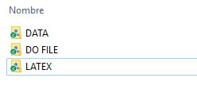

Folders

## Preambulo y directorios

Lo primero que debemos realizar es lo usual en un preambulo, que es *clear all* y *set more off*. El primero permite operar con un Stata completamrnte vacío y el segundo permite no tener que clickear en *more* cuando ejecutemos programas muy largos.

```
//      TALLER STATA SESION #3
//      AUTOR: ALVARO GUTIERREZ VARGAS
//      FECHA ULTIMA MODIFICACION : 28-03-2018
//===========================================================================//
//  PRELIMINARES
clear all  /*Elimina todo en el stata (base de datos, matrices, locals, etc)*/
set more off  /*Impide que tengamos que estar clickeando "more" cuando el do es muy largo*/
```

# Gen, Egen y Bys:

## Gen

Este comando nos permite generar variables nuevas en nuestra base de datos. También nos permite ocupar operadores lógicos para dicha construcción.

### (I) Jefe de Hogar.

La variable Jefe de Hogar corresponde a la variable *a5*. Por lo que podemos inspeccionarla con el comando tabulate.

```
. tabulate a5


        a5. ¿qué |
     relación de |
parentesco tiene |
 con respecto al |
  jefe de hogar? |      Freq.     Percent        Cum.
-----------------+-----------------------------------
   jefe de hogar |     14,244       19.24       19.24
cónyuge o pareja |     11,041       14.91       34.15
         hijo(a) |     25,804       34.85       69.00
   otro familiar |     19,976       26.98       95.97
otro no familiar |      2,982        4.03      100.00
-----------------+-----------------------------------
           Total |     74,047      100.00
```

Acá vemos que la variable cuenta con una *label*, lo que significa que visualizamos una **mascara** del número real que se encuentra almacenado en ella. Si quisieramos acceder a la variable “plana”, tendremos que adicionar la opción *nolabel*, al comando tabualte:

```
tabulate a5, nolabel

   a5. ¿qué |
   relación |
         de |
 parentesco |
  tiene con |
respecto al |
    jefe de |
     hogar? |      Freq.     Percent        Cum.
------------+-----------------------------------
          1 |     14,244       19.24       19.24
          2 |     11,041       14.91       34.15
          3 |     25,804       34.85       69.00
          4 |     19,976       26.98       95.97
          5 |      2,982        4.03      100.00
------------+-----------------------------------
      Total |     74,047      100.00
```

Ahora podemos ver que el número que corresponde al jefe de hogar es el 1 en esta variable. Ahora, sabiendo esto, podremos generar una variable *dummy* que tome el valor 1 cuando el encuestado sea el jefe de hogar, con los comandos *gen* y *replace*. Primero generaremos una variable llena de ceros llamada *jefe* y luego reemplzaremos dicha variable con un 1 cuando a5 sea igual a 1 (es decir sea el jefe de hogar.).

```
. gen jefe = 0

. replace jefe = 1 if a5 ==1
(14,244 real changes made)
```

Notar que la estructura del replace es la siguiente: Primero decirle que variable queremos reemplazar y con qué valor, en este caso: *replace jefe =1*. Luego se le entrega la condición lógica *if a5 ==1*. Notar que luego del **if** van **DOS signos de igualdad**, lo que es un error común para la gente que inicia en el lenguaje, la que escribe:

```
replace jefe = 1 if a5 =1
invalid syntax
r(198);
```

Obteniendo un error de invalid sintax!

### (II) Variable Genero

Siguiendo el mismo procedimiento descrito:

```
. gen male = .
(74,047 missing values generated)

. replace male   = 1 if a8 ==1
(36,308 real changes made)

. replace male = 0    if a8 ==2
(37,652 real changes made)
```

### (III) Variable Ingreso

Es usual que en las encuestas se codifiquen las respuestas “no sabe” o “no responde” con números como 99 o 999. Estos valores, al no ser extraídos desde la distribución evitentemente ensuciarán los datos dado que fueron generados de forma artificial para demarcar la no respuesta. Por esto, debemos limpiar la base de datos antes de proceder.

Primero observemos la variable *c3* que ocntiene el ingreso del individuo.

```
tabulate  c3

 c3. en el |
    trabajo |
 principal, |
durante los |
 últimos 12 |
     meses, |
  ¿cuál fue |
el ingreso  |      Freq.     Percent        Cum.
------------+-----------------------------------
          0 |         16        0.12        0.12
no responde |        297        2.22        2.34
    no sabe |      4,187       31.36       33.71
       1200 |          1        0.01       33.71
       3500 |          1        0.01       33.72
       5000 |         11        0.08       33.80

[Output completo omitido: en pro de la parsimonia]

    4800000 |          1        0.01       99.98
    9600000 |          1        0.01       99.99
   1.00e+07 |          1        0.01       99.99
   1.50e+07 |          1        0.01      100.00
------------+-----------------------------------
      Total |     13,351      100.00
```

Acá vemos que existen las categorías “no sabe” y “no responde”, de este modo aplicando *nolabel* podemos ver cuales son los numeros que almacenan estas categorías.

[output not shown]

```
. gen ingreso = c3
(60,696 missing values generated)

.  replace ingreso = . if c3 ==8 | c3 ==9
(4,484 real changes made, 4,484 to missing)
```

Acá aprovechamos de introducir un nuevo operador lógico *|*, el cual en significa “ó”. Con lo que la condición lógica que recién escribimos puede entenderse como: *“reemplaza a **ingreso** con un punto (missing) si c3 es 8 ó si es 9”*

Otra forma de haber escrito la condición anterior es haber ocupado el comando *inrange* o *inlist*.

#### inlist

```
. replace ingreso = . if inlist(c3,8,9)
(0 real changes made)
```

#### inrange

La otra forma con la que esto pudo haber sido computado es con *inrange* Este comando, opera de la misma forma que *inlist*, la única diferencia radica en que ahora no operará con valores puntuales, sino que operará con un rango de valores.

```
. replace ingreso = . if inrange(c3,8,9)
(0 real changes made)
```

En simple, lo que acabamos de escribir se lee *“reemplaza la variable ingreso con un punto (missing) si c3 posee los valores **ENTRE** 8 y 9”* Lo que en este caso es equivalente, tal cual nos muestra el output de Stata (0 real changes made).

### (IV) Dummy Ingreso inferior a $250.000.

siguiendo los procedimientos anteriores fluye que:

```
. gen ing_less_min = 0

. replace ing_less_min = 1 if ingreso <250000
(6,272 real changes made)
```

### (V) Mujeres que ganan más de un millón

Para genera esta variable se deben complir dos condiciones lógicas simultáneamente, que el ingreso sea superior a un millón y que cumpla cons er mujer. Acá podemos introducir el operador lógico “y”, el cual en Stata corresponde a *&*. De esto, es natural que la variable sea creaca como:

```
. gen ing_female_1mm = 0

. replace ing_female_1mm = ingreso if ingreso >1000000 & male ==0
(34,287 real changes made, 34,260 to missing)
```

## EGEN

### (I)Variable “Hogar”

Acá recurrimos a la función [egen](https://www.stata.com/manuals13/degen.pdf), la cual tiene un roll increíblemente preponderante en la programación en Stata. Esta posee muchas “sub” funciones útiles, en el manejo de bases de datos. Una de ellas es la función *group* la que nos permite generar un número correlativo ( del 1 al final de la base), en base a alguna variable que deseemos. En este caso, queremos obtener un correlativo de los hogares en la muestra, los cuales está indentificados con la variable “folio”.

```
egen hogar= group(folio)
```

### (II) Recortando la Base (groseramente)

Ahora para quedarnos solo con los tres primeros hogares, podemos ocupar el comando *keep* el cual al combinarlo con *if* nos permite quedarnos con los hogares del 1 al 3.

```
keep if hogar <4
```

Si computamos *browse* (aberviado con *br*) y la lista de variables que deseemos observar en el data set obtendremos:

```
br  folio   hogar   a4  male
```

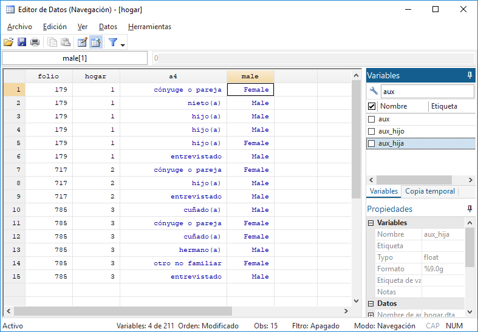

browse_inicial

Desde esta última imagen podemos ver varias cosas:

1. Solo se quedaron los hogares con folio 179, 717 y 785
2. Estos fueron nominados con los números correlativos 1, 2 y 3. Con lo que comprobamos que quedó generada correctamente la variable “hogar”
3. En el primer hogar existen 6 personas, en el segundo 3 y en el tercero 6.
4. En el primer hogar existen 3 hijos, en el segundo solo uno y en el tercero no existen hijos.
5. En el primer hogar existen 2 mujeres, en el segundo solo una y en el tercero 3.

### (III) Numero de Personas en el Hogar

Esto en general es un dolor de cabeza para los que inician en el Stata, o en general cualquier tipo de programación con data jerarquizada. En este caso tenemos una sola jerarquía relevante: *Hogar-Invididuo*. Afortunadamente Stata es bastante directo realizar cálculos a niveles gerárquinos, con su opción **bys:**.

Para poner las cosas en simple. Generemos una variable auxiliar que contenga solamente unos.

```
gen aux = 1
```

Ahora ocupemos esta variable para realizar el conteo de personas en el hogar. En el fondo necesitamos que Stata vaya contando *por cada hogar* la cantidad de personas (en este caso, cada persona será un 1 en la variable *aux*). Esta operación se realiza con una sub función de *egen* llamada *total*, combinada con bysort

```
bysort hogar : egen numper = total(aux)
```

Esta simple linea, puede ser descompuesta en 3 partes:

1. *bysort hogar :* Para cada hogar, realiza la operación que viene luego de los dos puntos
2. *egen numper =* Vamos a generar una nueva variable llamada **numper**, la cual será igual a….
3. *total(aux)* a la sumatoria de la variable aux. Es decir, en nuestro caso a la sumatoria del número de integrantes del hogar, o en otras palabras al **numero de personas en el hogar**.

### (VI) Número de Hij@s en el Hogar

Dado las explicaciones anteriores, debería resultar natural para el lector crear la variable número de hij@s como:

```
gen aux_hijo = 0

replace aux_hijo = 1 if a4 ==3
(4 real changes made)

bys hogar : egen num_hijo = total(aux_hijo)
```

### (VII) Número de Hijas en el Hogar

Seguiendo la misma lógica y lo aprendido en este taller, vemos que ahora solamente debe cumplir una condición adocional (ser mujer: male ==0).

```
gen aux_hija = 0

replace aux_hija = 1 if a4 ==3 & male ==0
(1 real change made)

bys hogar : egen num_hija = total(aux_hija)
```

Con lo que obtendremos:

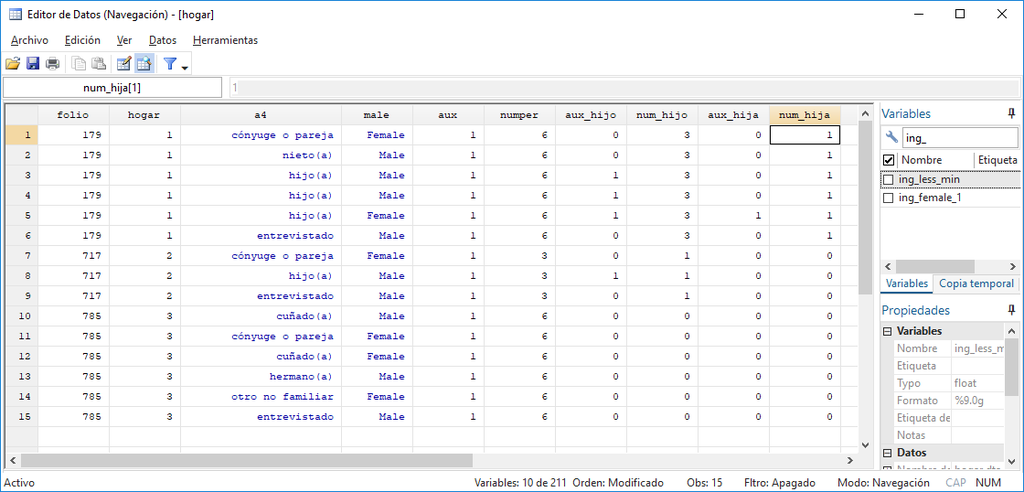

browse_inicial

## Labels

Los labels son las etiquetas que nos permiten operar una base de datos de forma más amigable, ya que en vez de solamente ver números, podemos generar etiquetas sobre *valores* y *variables* para que la visualización de la data sea más sencilla. Por ejemplo, en el caso del ejemplo si realizamos un *tabulate* sobre la variable *male* que creamos en este tutorial obtendremos:

```
 tabulate male

       male |      Freq.     Percent        Cum.
------------+-----------------------------------
          0 |          6       40.00       40.00
          1 |          9       60.00      100.00
------------+-----------------------------------
      Total |         15      100.00
```

Lo cual no es para nada informativo…

### Label values (male)

Primero pondremos etiquetas sobre los números de la variable male. Esto se realiza en dos pasos:

1. Se genera la etiqueta con:

   ```
   label define male 1 "Male" 0 "Female"
   ```

   Lo que acabamos de realizar es **definir** la etiqueta llamada *male* (convenientemente igual al nombre de la variable, esto no es obligación), en donde los 1 tendrán por máscara “Male” y los 0 tendrán “Female”
2. Ahora debemos asignarle la mascara que acabamos de crear a la variable male con el comando:

   ```
   label values male male
   ```

   En donde le ordenamos a Stata que asigne a la variable *male* la etiqueta *male* que acabamos de crear.

### Label variables

También nos podría interesar que la variable completa tuviera una etiqueta, lo que será útil a la hora de exportar tablas de regresión lineal o simplemente explorar la base de forma rápida. Podemos asignarle una etiqueta a la **variable** mediante:

```
label variable male "Gender [Male =1]"
```

Con lo que obtendremos algo **MUCHO** más informativo.

```
. tabulate male

     Gender |
  [Male =1] |      Freq.     Percent        Cum.
------------+-----------------------------------
     Female |          6       40.00       40.00
       Male |          9       60.00      100.00
------------+-----------------------------------
      Total |         15      100.00
```

## Recode

Para finalizar, presentaremos un comando que, básicamente, encompaza a todos los que hemos descrito hasta acá… **recode**.

Este nos permite, simultáneamente, generar una nueva variable discreta, a partir otra variable, ya sea continua o discreta, adhiriendo los *labels* respectivos simultáneamente. En este caso, generaremos una variable llamada *tramoedad* que contendrá 6 tramos de edad apartir de la variable a9.

Antes de introducir las últimas lineas de esta sesión vale la pena recordar que una forma sencilla de programar *una linea* muy larga, que será dificil de visualizar en nuestra pantalla es declarar un espacio especial en donde Stata entenderá que todo lo que esté ahí, será una misma linea. Entonces…

Esto…

```
# delimit ;
recode a9 (0/14 = 1 "Menores de 15")
                (15/29 = 2 "15 a 29 años")
                (30/45 = 3 "30 a 45")
                (46/55 = 4 "46 a 55")
                (56/65 = 5 "56 a 65")
                (66/max =6 "66 y más")
,g(tramoedad)
;
# delimit cr
```

Será equivalente a…

```
recode a9 (0/14 = 1 "Menores de 15") (15/29 = 2 "15 a 29 años") (30/45 = 3 "30 a 45") (46/55 = 4 "46 a 55") (56/65 = 5 "56 a 65")   (66/max =6 "66 y más"),g(tramoedad)
```

Por lo que aprendemos que:

```
# delimit ;
TODO LO QUE ESTÉ DENTRO DE ESTE AMBIENTE SERÁ ENTENDIDO COMO UNA SOLA LINEA!
;
# delimit cr
```

Volviendo al *recode*. Recodificaremos la variable a9 en sus tramos. La sintaxis es la siguiente:

1. recode *nombre de la variable*: que queremos recodificar.
2. (0/14 = 1 “Menores de 15”): Esto significa que para los valores entre 0 y 14, se asigará un 1 y la etiqueta *“Menores de 15”*
3. ,g(tramoedad): Esto le indica a Stata que queremos que genere una nueva variable llamada *tramoedad* con lo recién declarado.

Con lo que finalmente obtendremos:

```
 tabulate tramoedad

 RECODE of a9 |
    (a9. ¿qué |
         edad |
   tiene...?) |      Freq.     Percent        Cum.
--------------+-----------------------------------
Menores de 15 |          1        6.67        6.67
      30 a 45 |          3       20.00       26.67
      46 a 55 |          2       13.33       40.00
      56 a 65 |          3       20.00       60.00
     66 y más |          6       40.00      100.00
--------------+-----------------------------------
        Total |         15      100.00
```